# Machine Learning in Risk and Finance

### Developing a Residual Value Risk Model

by [Julian Dörr](https://juliandoerr.com)

## About this Course

### What you will learn

- **Fundamental Concepts**: Overview of ML and its relationship with Artificial Intelligence (AI) and Deep Learning (DL).
- **ML in Risk Modelling**: Application of ML in managing residual value risk in car leasing.
- **Developing a ML Risk Model**: Based on a real-world use case:
  - Problem understanding
  - Data preprocessing
  - Feature selection
  - Model training
  - Model evaluation
- **Commonly Used ML Algorithms**: Overview of Bagging and Boosting methods.
- **Data Splitting Process**: Techniques for splitting data into training and test sets, including sampling strategies like cross-validation.
- **ML Pipeline**: Automate the inference process of applying the ML model.

## What is Machine Learning?

To grasp the definition of Machine Learning (ML), it's helpful to narrow the focus by exploring its relationship with Artificial Intelligence (AI) and Deep Learning (DL).

ML is a subset of AI that focuses on developing algorithms capable of learning from data to make predictions or decisions, while DL is a specialized branch of ML that utilizes neural networks to model complex patterns in large datasets.

[figure not shown]

Image source: Author

**Artificial Intelligence (AI)**  
AI is the overarching field that encompasses all technologies and systems designed to **simulate human intelligence**. This includes tasks like reasoning, problem-solving, learning, and decision-making.

**Machine Learning (ML)**:  
ML is a subset of AI that involves **constructing predictive models from labeled datasets**, enabling systems to make informed decisions based on data. It is categorized into three main types:

- **Supervised Learning**: The model learns from labeled data, where input-output pairs are provided, allowing it to predict outcomes for new, unseen data.
- **Unsupervised Learning**: The model identifies patterns and structures in unlabeled data, discovering hidden relationships without predefined labels.
- **Reinforcement Learning**: The model learns through interactions with an environment, receiving rewards or penalties based on its actions, which guides its decision-making process.

In this course, we will focus specifically on supervised learning, utilizing tree-based regression methods to develop predictive models.

**Deep Learning (DL)**:  
Deep learning is a specialized branch of ML that uses **artificial neural networks** inspired by the human brain. These networks are particularly effective at processing large amounts of **unstructured data**, such as images, text, and audio.

## Application of Machine Learning in Risk Management

Machine Learning (ML) has become an essential tool in **risk management** due to its ability to **analyze vast amounts of data** and **uncover patterns that traditional methods may overlook**. In today's complex financial landscape, organizations face numerous risks, and ML provides a robust framework for modeling and steering these risks effectively.

### Why Use Machine Learning?

1. **Enhanced Predictive Accuracy**: ML algorithms improve risk predictions by learning from historical data and adapting to new information, crucial for credit risk modeling.
2. **Real-Time Analysis**: ML processes data in real-time, enabling swift responses to emerging risks in dynamic markets.
3. **Complex Data Handling**: ML excels at processing vast amounts of complex financial data, allowing for comprehensive risk assessments.
4. **Model Risk Management**: ML helps identify and mitigate model risk by providing insights into model performance and reliability.
5. **Automation and Efficiency**: ML automates routine risk assessment tasks, freeing up resources for strategic decision-making, especially in credit risk management.

### A real-world use case: Residual Value Risk Modelling

In the following, we will work on a real-world use case that **car leasing entities** typically face. It is the risk associated with the **uncertainty of what a leased out car can be resold at** when the car returns to the leasing entity. This asset risk is commonly known as residual value risk.

Cars depreciate at different speed.

[figure not shown]

Image source: [Diminished Value of Georgia](https://diminishedvalueofgeorgia.com/the-top-10-slowest-depreciating-used-cars-in-the-u-s/)

**Why do leasing companies care about residual values?**

Leasing companies prioritize residual values because they are essential for **estimating** an asset's worth at the end of its lease term, which influences **lease payments** and financial risk management. Accurate predictions of residual values help **prevent financial losses when remarketing used vehicles**.

**What determines the residual value of a vehicle?**

The residual value of a vehicle is determined by various factors, including its **condition** (age, mileage, and damage), shifting **customer preferences**, **economic fluctuations**, **market transparency**, advancements in **technology** (like electric vehicles), and **regulatory uncertainties**, making accurate predictions challenging.

## Developing a Machine Learning Model

Developing a ML model involves a multi-step process that is typically organized into pipeline structures.

[figure not shown]

Image source: Author

### Understanding the Problem

Creating a residual value model is a regression task focused on **predicting the future resale price of a vehicle** at the end of its lease term, leveraging features like vehicle characteristics. The starting point for the model development is **historical resale data** that then needs to undergo a thorough cleaning and feature engineering process. We work with used car data for the US market that is freely available on [Kaggle](https://www.kaggle.com/datasets/mdnizamsapiee/vehicles-csv/data).

### Data Preprocessing

#### Data Cleaning

First, we import `pandas` a popular Python library that is designed to wrangle rectangular data.

```python
import pandas as pd
pd.set_option('display.float_format', '{:.2f}'.format)
```

Then we read the data used car data.

```python
df_uc = pd.read_csv('data/used_car.csv', parse_dates=['posting_date'])
```

How many observations (samples) and variables (features) do we have?

```python
df_uc.shape
```

```
(426812, 17)
```

Overall, there 17 features with 426,812 samples.

Next, we will take a first look at the data and examine the data types.

```python
df_uc.sample(3)
```

|  | id | region | price | year | manufacturer | model | condition | cylinders | fuel | odometer | transmission | VIN | drive | type | paint_color | state | posting_date |
| --- | --- | --- | --- | --- | --- | --- | --- | --- | --- | --- | --- | --- | --- | --- | --- | --- | --- |
| 251482 | 7308468451 | central NJ | 1750 | 2003.00 | chevrolet | suburban 1500 | fair | 8 cylinders | gas | 185234.00 | automatic | NaN | 4wd | SUV | black | nj | 2021-04-17 |
| 413799 | 7314940510 | charleston | 32990 | 2013.00 | tesla | model s signature | good | NaN | electric | 62588.00 | other | 5YJSA1DP8DFP06269 | rwd | sedan | white | wv | 2021-04-30 |
| 255196 | 7311946676 | north jersey | 18995 | 2014.00 | mercedes-benz | e-class | NaN | NaN | gas | 51263.00 | automatic | WDDHF8JB4EA864900 | NaN | other | white | nj | 2021-04-24 |

```python
df_uc.dtypes
```

```
id                       int64
region                  object
price                    int64
year                   float64
manufacturer            object
model                   object
condition               object
cylinders               object
fuel                    object
odometer               float64
transmission            object
VIN                     object
drive                   object
type                    object
paint_color             object
state                   object
posting_date    datetime64[ns]
dtype: object
```

Note the following definition of data types:

- `int64`: integer type.
- `float64`: floating point type.
- `object`: generic container for any Python object (here used for string variables)
- `datetime64[ns]`: date and time information with nanosecond precision

The automatic data type conversion of pandas seems to make sense.

To avoid skewing the learning process, it is essential to **eliminate duplicate entries** from our data, as machine learning models may assign undue importance to these duplicates, particularly if they belong to a specific class. This can lead to a **biased model** that fails to accurately represent the true distribution of the data.

```python
df_uc.drop(columns=['id']).duplicated().sum().__str__()
```

```
'4222'
```

There are 4222 duplicates in our raw data. We keep only the first entry.

```python
df_uc = df_uc.drop(columns=['id']).drop_duplicates(keep='first')
```

A common approach to gain initial insights into the variables is by examining their **descriptive statistics**, which can be easily accomplished using the pandas method `describe()`. This method provides a summary of key statistical measures, helping to **understand the distribution and characteristics of the data**.

```python
# Descriptive stats for integers, floats and datetime
df_uc.describe(exclude=['object'])
```

|  | price | year | odometer | posting_date |
| --- | --- | --- | --- | --- |
| count | 422590.00 | 421475.00 | 418324.00 | 422590 |
| mean | 75774.14 | 2011.23 | 97993.36 | 2021-04-23 08:18:04.557609216 |
| min | 0.00 | 1900.00 | 0.00 | 2021-04-04 00:00:00 |
| 25% | 5950.00 | 2008.00 | 37531.00 | 2021-04-17 00:00:00 |
| 50% | 13988.00 | 2013.00 | 85377.00 | 2021-04-25 00:00:00 |
| 75% | 26500.00 | 2017.00 | 133600.00 | 2021-05-01 00:00:00 |
| max | 3736928711.00 | 2022.00 | 10000000.00 | 2021-05-05 00:00:00 |
| std | 12243930.69 | 9.47 | 213704.62 | NaN |

We have identified several outliers in the data:

- maximum `price` of $3,736,928,711 is unreasonably high for a used car.
- maximum `odometer` reading of 10,000,000 is also unrealistic.
- a model `year` of 1900 seems to be another data quality issue.

In the following we remove these outliers.

```python
# 1: Remove samples with a price >= 100000
df_uc = df_uc.loc[df_uc['price']<100000]

# 2: Remove samples with a year < 2000
df_uc = df_uc.loc[df_uc['year']>=2000]

# 3: Remove samples with a odometer > 200000
df_uc = df_uc.loc[df_uc['odometer']<=200000]
```

```python
# Descriptive stats for strings only
df_uc.describe(include=['object'])
```

|  | region | manufacturer | model | condition | cylinders | fuel | transmission | VIN | drive | type | paint_color | state |
| --- | --- | --- | --- | --- | --- | --- | --- | --- | --- | --- | --- | --- |
| count | 372280 | 361468 | 369065 | 218465 | 214072 | 370244 | 370764 | 247417 | 259796 | 297770 | 261213 | 372280 |
| unique | 404 | 41 | 23395 | 6 | 8 | 5 | 3 | 108744 | 3 | 13 | 12 | 51 |
| top | columbus | ford | f-150 | good | 6 cylinders | gas | automatic | 1FMJU1JT1HEA52352 | 4wd | sedan | white | ca |
| freq | 3194 | 60453 | 7019 | 106911 | 83390 | 310918 | 293591 | 261 | 117001 | 80398 | 69925 | 43164 |

Looking at `manufacturer`, for example, we see that

- there is remarketing data from 41 distinct manufacturers
- the most frequent manufacturer is Ford
- with 60,453 observations

Alternatively, we can visualize the univariate distribution of each variable. To facilitate this, I have provided a convenient function called `plot_univariate()`, which can be found in the util.py module.

```python
from util import plot_univariate
```

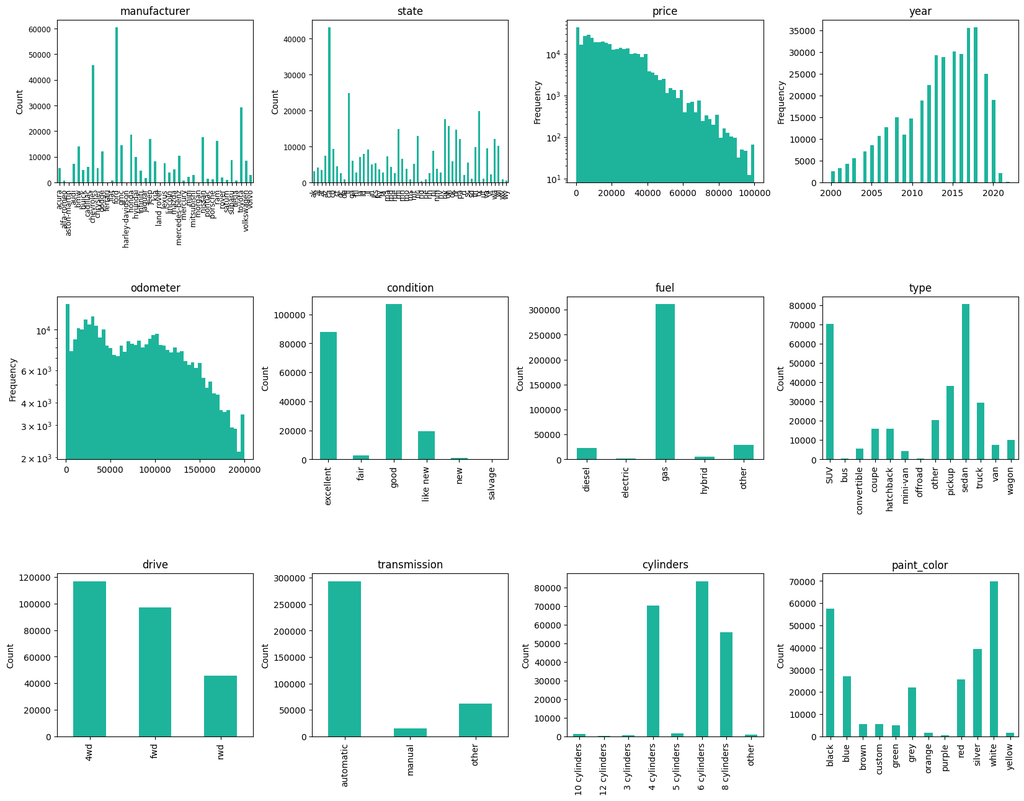

```python
plot_univariate(
    df_uc,
    columns=[
        'manufacturer', 'state', 'price', 'year', 'odometer',
        'condition', 'fuel', 'type', 'drive', 'transmission',
        'cylinders', 'paint_color'],
    log_dict={'price': True, 'odometer': True},
    ncols=4, size=(20,15), wspace=.3)
```

The plot indicates that the dataset includes **used car prices from various manufacturers across different states in the US** and model years, with **significant variance in odometer** readings, a key factor in determining a used car's residual value. To refine the analysis, we will remove samples with prices below $1,000, as they are not relevant in the context of residual value assessment.

```python
df_uc = df_uc.loc[df_uc['price'] > 1000]
```

In the context of residual value risk management, we aim to determine whether we can **train a model that accurately predicts the residual value**, or used-car price, **based on vehicle information* available at the *inception* of the lease contract.

Translating these questions into a ML problem can be stated as follows:

```python
# Target variable
y = df_uc['price']
```

```python
# Features
X = df_uc.drop(columns=['price'])
```

#### Train-Test Split

In machine learning projects, splitting the dataset into **training** and **test** sets is essential.

**Why Split the Data?**

1. **Model Evaluation**: Train the model on the training set and evaluate its performance on the test set to ensure it generalizes well to new data.
2. **Prevent Overfitting**: Monitor and mitigate overfitting by keeping a separate test set. Overfitting occurs when a model performs well on training data but poorly on new data. Later in the course, we will learn about cross-validation to further prevent overfitting.

**When to Split the Data?**

- **Early in the Pipeline**: Splitting early ensures data integrity and prevents data leakage, maintaining an unbiased estimate of the model's performance.

We **split the data at random into training and test sets** using the `train_test_split()` method from the popular `scikit-learn` library that provides a wide range of ML algorithms and other convenience functions that are typically used in ML pipelines. We will **keep 20% of the data aside** in the test set. For reproducibility we set a seed via the `random_state` argument.

```python
from sklearn.model_selection import train_test_split
```

```python
X_train, X_test, y_train, y_test = train_test_split(
    X, y, test_size=0.2, random_state=333)
```

#### Handling Missing Values

Most **machine learning models cannot handle missing values**, so we employ **data imputation to replace these missing values with reasonable substitutes**, which helps maintain the model's ability to learn from the training data. This method is preferred over simply dropping samples with missing values, as it preserves more observations and, consequently, more patterns for the model to learn.

```python
X_train.isnull().sum()
```

```
region               0
year                 0
manufacturer      7169
model             2011
condition       101347
cylinders       111302
fuel              1601
odometer             0
transmission      1087
VIN              90247
drive            79740
type             51882
paint_color      73975
state                0
posting_date         0
dtype: int64
```

Most of the features have missing values. There are different imputation strategies and, depending on the feature, one or the other makes more sense.

##### year

Domain knowledge is crucial for defining an effective imputation approach for vehicle data. The 10th character of the Vehicle Identification Number (VIN) specifically indicates the vehicle's model year. The VIN serves as a unique identifier for each vehicle and is included in our dataset

[figure not shown]

Image source: [AutoCheck](https://www.autocheck.com/vehiclehistory/vin-basics)

We import a dictionary that maps the 10th digit of the VIN to the model year. The dictionary can be read from the util.py module.

```python
from util import vin_to_year
```

```python
X_train.loc[X_train.year.isnull(), 'year'] = X_train.loc[
    X_train.year.isnull()].VIN.apply(lambda x: x[9]).map(vin_to_year)
```

##### manufacturer

The same applies to the manufacturer. 2nd and 3rd character of the VIN give information about the car manufacturer. Again, we use this information to impute the manufacturer column.

```python
from util import vin_to_manufacturer
```

```python
X_train.loc[
    X_train.manufacturer.isnull() & X_train.VIN.notnull(),
    'manufacturer'
] = X_train.loc[
    X_train.manufacturer.isnull() & X_train.VIN.notnull()
].VIN.apply(lambda x: x[0:3]).map(vin_to_manufacturer)
```

##### model

A valid imputation strategy for categorical variables is to introduce a new category labeled "unknown" to replace missing values. We will implement this approach for the model column using the `SimpleImputer` class from `scikit-learn`.

```python
from sklearn.impute import SimpleImputer
```

```python
X_train[['model']] = SimpleImputer(
    strategy='constant',
    fill_value='unknown').fit_transform(X_train[['model']])
```

##### paint_color

We can use the `SimpleImputer` also to impute missing values with the most frequent value. We do so for the paint_color variable.

```python
X_train[['paint_color']] = SimpleImputer(
    strategy='most_frequent').fit_transform(X_train[['paint_color']])
```

```python
from util import ConditionalImputer
from tqdm import tqdm
```

```python
columns_to_impute = ['cylinders', 'fuel', 'transmission', 'drive']
```

```python
for column in tqdm(columns_to_impute):
    # Create a list of condition columns excluding the current target column
    relevant_cols = ['manufacturer', 'type'] + [column]

    # Impute the target column using the adjusted condition columns
    X_train[column] = ConditionalImputer(
        target_col=column,
        condition_cols=['manufacturer', 'type'],
        strategy='most_frequent').fit_transform(X_train[relevant_cols])[column]
```

##### odometer

An intuitive imputation strategy for the odometer (miles driven) is to assume that **older cars generally have on average a higher mileage**. To implement this, we first calculate the vehicle's age by determining the difference between the model year and the posting date.

```python
X_train['age'] = X_train['posting_date'].dt.year - X_train['year']
```

We now impute the missing odometer with the most similar used cars in terms of vehicle age. For this purpose, we use `scikit-learn`'s `KNNImputer` class.

```python
from sklearn.impute import KNNImputer
```

```python
X_train[['age', 'odometer']] = KNNImputer(
    n_neighbors=10).fit_transform(X_train[['age', 'odometer']])
```

The remaining observations with missing values are going to be dropped.

```python
X_train = X_train.loc[X_train.drop(
    columns=['VIN', 'condition']).notnull().all(axis=1)]
y_train = y_train.loc[X_train.index]
```

```python
X_train.isnull().sum()
```

```
region              0
year                0
manufacturer        0
model               0
condition       99550
cylinders           0
fuel                0
odometer            0
transmission        0
VIN             86985
drive               0
type                0
paint_color         0
state               0
posting_date        0
age                 0
dtype: int64
```

```python
X_train.shape
```

```
(259935, 16)
```

### Feature Engineering

#### Feature Selection

When selecting features for a machine learning model, it's essential to **ensure that the information is available at the time of inference**, particularly in risk management where predictions, such as lease rates based on residual values, must be made at the start of a lease without relying on end-of-lease data.

Key Considerations:

- The car's sale **region** is unknown at the lease's start, so we disregard it unless the off-lease strategy is pre-planned.
- The vehicle's final **condition** is also unknown.
- **Age** and **mileage** can be estimated from the contractual lease period and maximum mileage.

```python
X_train = X_train.drop(columns=['condition', 'region', 'state', 'VIN'])
```

Further feature engineering involves **creating new features** to enhance a model's predictive power. For instance, we have derived the **age** feature from the manufacturing year and the posting date of the used car.

```python
X_train = X_train.drop(columns=['year', 'posting_date'])
```

**Special equipment**, such as sport packages, often **depreciates faster** than standard vehicles. We can utilize the model variable to determine if a vehicle is a "sports version".

```python
X_train['sport'] = X_train['model'].apply(
    lambda x: 'sport' in x.lower()).astype(int)
```

```python
X_train = X_train.drop(columns=['model'])
```

One could consider additional feature engineering steps. For instance, the counting how often the same VIN occurs in the data could serve as a proxy for the number of previous owners. However, this is beyond the scope of this course.

#### Encoding Categorical Variables

Encoding categorical variables is essential before training a machine learning model, as most **ML algorithms require numerical input** and cannot process categorical data directly. Techniques like **one-hot encoding**, which **converts each category into a binary vector**, can be implemented using the `OneHotEncoder` class from `scikit-learn`.

```python
from sklearn.preprocessing import OneHotEncoder
```

```python
# Step 1: Fit and transform the data
encoder = OneHotEncoder(
    sparse_output=False,
    min_frequency=5,
    handle_unknown='infrequent_if_exist').fit(
        X_train[['manufacturer', 'fuel', 'cylinders',
                 'paint_color', 'type', 'drive', 'transmission']])

# Transform the data
encoded_data = encoder.transform(
    X_train[['manufacturer', 'fuel', 'cylinders',
             'paint_color', 'type', 'drive', 'transmission']])
```

```python
# Step 2: Create a DataFrame from the encoded data
encoded_df = pd.DataFrame(
    encoded_data, columns=encoder.get_feature_names_out())
```

```python
# Step 3: Concatenate the original DataFrame with the encoded DataFrame
X_train = pd.concat([
    X_train.reset_index(drop=True),
    encoded_df.reset_index(drop=True)],
    axis=1)
```

```python
# Step 4: Drop the original categorical columns if no longer needed
X_train.drop(
    columns=['manufacturer', 'fuel', 'cylinders',
             'paint_color', 'type', 'drive', 'transmission'],
    inplace=True)
```

All features are now converted into numerical format.

```python
X_train.head(3)
```

|  | odometer | age | sport | manufacturer_acura | manufacturer_alfa-romeo | manufacturer_aston-martin | manufacturer_audi | manufacturer_bmw | manufacturer_buick | manufacturer_cadillac | ... | type_sedan | type_truck | type_van | type_wagon | drive_4wd | drive_fwd | drive_rwd | transmission_automatic | transmission_manual | transmission_other |
| --- | --- | --- | --- | --- | --- | --- | --- | --- | --- | --- | --- | --- | --- | --- | --- | --- | --- | --- | --- | --- | --- |
| 0 | 86000.00 | 8.00 | 0 | 0.00 | 0.00 | 0.00 | 0.00 | 0.00 | 0.00 | 0.00 | ... | 1.00 | 0.00 | 0.00 | 0.00 | 1.00 | 0.00 | 0.00 | 0.00 | 1.00 | 0.00 |
| 1 | 52159.00 | 2.00 | 0 | 0.00 | 0.00 | 0.00 | 0.00 | 0.00 | 0.00 | 0.00 | ... | 0.00 | 0.00 | 0.00 | 0.00 | 1.00 | 0.00 | 0.00 | 1.00 | 0.00 | 0.00 |
| 2 | 107862.00 | 6.00 | 0 | 0.00 | 0.00 | 0.00 | 0.00 | 0.00 | 0.00 | 0.00 | ... | 0.00 | 0.00 | 1.00 | 0.00 | 0.00 | 1.00 | 0.00 | 1.00 | 0.00 | 0.00 |

3 rows × 91 columns

### Model Training

A crucial step in the development of a ML model is that **different algorithms have varying strengths and weaknesses**, and selecting the most suitable one can significantly impact the model's performance and accuracy.

The number of algorithms for supervised learning tasks for regression is relatively wide spread. A good overview can be found [here](https://scikit-learn.org/stable/supervised_learning.html).

In this course we focus on **tree-based models**. The basic building block, also known as base learner, in a tree-based model is a **Decision Tree**.

#### Decision Tree

Decision Tree Logic:

- **Splitting**: The data is divided into subsets based on feature values to identify the best feature and split point that separate the data according to the target variable.
- **Decision Rules**: Each node represents a binary decision rule based on a feature, such as "Is feature X greater than value Z?"
- **Leaf Nodes**: Terminal nodes (leaves) provide the model's prediction, typically the mean value of the target variable for samples in that leaf.

```python
from sklearn import tree
```

```python
model = tree.DecisionTreeRegressor(
    max_depth=2,
    min_samples_leaf=1000).fit(X_train, y_train)
```

```python
tree_plot = tree.export_graphviz(
    model,                                                                                      # The trained decision tree model to visualize.
    feature_names=X_train.columns,                                                              # Names of the features used in the model for labeling nodes.
    filled=True,                                                                                # Fills the nodes with colors based on the predicted class.
    rounded=True,                                                                               # Draws node boxes with rounded corners for better aesthetics.
    special_characters=True,                                                                    # Allows the use of special characters in feature names for proper rendering.
    proportion=True,                                                                            # Displays the proportion of samples at each node instead of absolute counts.
    impurity=False,                                                                             # Omits impurity values (like Gini or entropy) from the node display.
    precision=0                                                                                 # Sets the precision for floating-point values to zero for cleaner output.
)
```

```python
import graphviz

graphviz.Source(tree_plot)
```

[figure not shown]

Decision trees are considered **weak learners** due to their tendency to **overfit** training data, particularly when they are deep, which can hinder their ability to generalize to unseen data. Conversely, shallow trees, or **stumps**, also exhibit weak learning characteristics as they capture limited information, resulting in high bias and low prediction accuracy.

Overfitting is related to the concepts of variance and bias:

- **High Variance**: Overfitting models have high variance, meaning they are too sensitive to the fluctuations in the training data.
- **Low Bias**: Overfitting models typically have low bias, meaning they fit the training data very closely.

[figure not shown]

Image source: Author

One effective way to visualize a model's performance is by **plotting its predictions against the true values**, which we will demonstrate next. This comparison allows us to assess how well the model captures the underlying patterns in the data.

```python
from util import plot_predictions
```

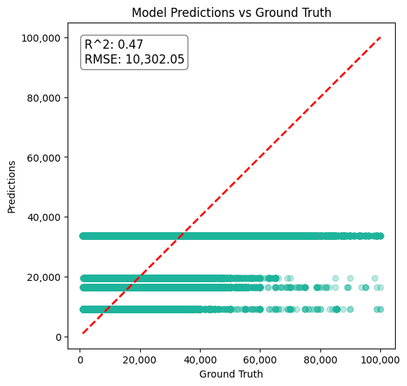

```python
y_pred = model.predict(X_train)
plot_predictions(y_train, y_pred)
```

#### Random Forest

Random Forest logic:

- **Ensemble of Trees**: It builds a large number of decision trees (hence "forest") and merges their results to improve accuracy and control overfitting.
- **Bootstrap Aggregation (Bagging)**: Each tree is trained on a random subset of the training data, sampled with replacement (bootstrapping). This helps in reducing variance.
- **Random Feature Selection**: At each split in the tree, a random subset of features is considered for splitting, which helps in reducing correlation among the trees and improves model robustness.

We train a Random Forest using `RandomForestRegressor` from `scikit-learn`. We control the training process by means of the following argument:

- `n_estimators`: The number of decision trees
- `max_depth`: The maximum depth of a tree
- `bootstrap`: Whether a random fraction of the samples should be used when training a tree, i.e. bootstrap sampling
- `max_features`: The number of features to consider when looking for the best split in a tree (sqrt(number_features))
- `random_state`: Since `bootstrap` and `max_features` add randomness to the training process, `random_state` sets a seed for reproducibility

```python
from sklearn.ensemble import RandomForestRegressor
```

```python
model = RandomForestRegressor(
    n_estimators=100,
    max_depth=20,
    bootstrap=True,
    max_features='sqrt',
    random_state=333).fit(X_train, y_train)
```

Model performance.

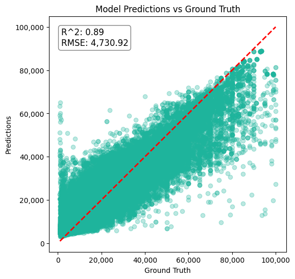

```python
y_pred = model.predict(X_train)
plot_predictions(y_train, y_pred)
```

#### Gradient Boosting

Gradient Boosting logic:

- **Sequential Learning**: Add decision trees one at a time. Each new tree is trained to predict the residual errors (the difference between the actual values and the predictions of the current model) of the combined ensemble of previous trees.
- **Gradient Descent**: The model uses gradient descent to minimize the loss function. The gradients of the loss function with respect to the model's predictions are used to fit the new tree.
- **Update Model**: The predictions of the new tree are added to the ensemble with a certain weight (learning rate), which controls the contribution of each tree.

```python
from sklearn.ensemble import GradientBoostingRegressor
```

```python
model = GradientBoostingRegressor(
    n_estimators=100,
    max_depth=20,
    learning_rate=0.1,
    max_features='sqrt',
    random_state=333).fit(X_train, y_train)
```

Model performance.

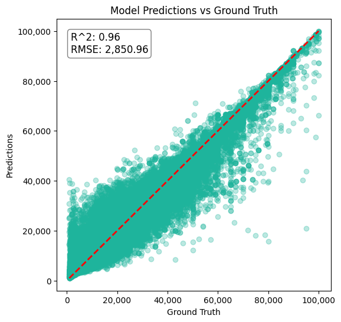

```python
y_pred = model.predict(X_train)
plot_predictions(y_train, y_pred)
```

### Model Fine Tuning

So far, we have arbitrarily **set the hyperparameters** of the machine learning models **without considering whether these values are optimal for minimizing prediction errors** in estimating vehicle residual values. Hyperparameters play a crucial role in determining the effectiveness of the model in achieving its predictive task.

Here are some key points about hyperparameters:

- **Predefined**: Hyperparameters are set manually before training the model.
- **Model Control**: They control aspects of the training process, such as the learning rate or the complexity of the model.
- **Tuning**: Hyperparameter tuning is the process of finding the optimal values for these parameters to improve model performance.

| Hyperparameters | Decision Tree | Random Forest | Gradient Boosting |
| --- | --- | --- | --- |
| `max_depth` | Maximum depth of the tree | Maximum depth of each tree | Maximum depth of each tree |
| `min_samples_split` | Minimum number of samples required to split an internal node | Minimum number of samples required to split an internal node | Minimum number of samples required to split an internal node |
| `min_samples_leaf` | Minimum number of samples required to be at a leaf node | Minimum number of samples required to be at a leaf node | Minimum number of samples required to be at a leaf node |
| `max_features` | Number of features to consider when looking for the best split | Number of features to consider when looking for the best split | Number of features to consider when looking for the best split |
| `criterion` | Function to measure the quality of a split (e.g., `mse`, `mae`) | Function to measure the quality of a split (e.g., `mse`, `mae`) | Loss function to be optimized (e.g., `mse`, `mae`) |
| `splitter` | Strategy used to choose the split at each node (e.g., `best`, `random`) | - | - |
| `n_estimators` | - | Number of trees in the forest | Number of boosting stages to be run |
| `bootstrap` | - | Whether bootstrap samples are used when building trees | - |
| `learning_rate` | - | - | Shrinks the contribution of each tree by `learning_rate` |

Important aspects of fine-tuning ML models:

- **Prevent Overfitting**: The goal is to find hyperparameters that generalize well to unseen data rather than just fitting the training data. **Cross-validation** is essential for assessing model performance on independent datasets and selecting optimal hyperparameters.
- **Computational Efficiency**: Testing all combinations of hyperparameters can be computationally expensive, so methods like **Grid Search** or **Random Search** are used to efficiently approximate the best hyperparameter configuration.

The cross-validation process involves splitting the dataset into k subsets, training the model on k-1 folds while validating it on the remaining fold, and repeating this k times to obtain an average performance metric.

[figure not shown]

Image source: Author

> **Grid Search** is a hyperparameter tuning technique that exhaustively searches through a specified subset of hyperparameters to find the optimal combination for a machine learning model.

> **Random Search** is a hyperparameter tuning technique that randomly samples a specified number of hyperparameter combinations from a given range to find the optimal set for a machine learning model.

[figure not shown]

Image source: Author

We will now implement **3-fold cross-validation using a Random Search strategy** to identify the optimal hyperparameters. We will use `RandomizedSearchCV` to do so.

```python
from sklearn.model_selection import RandomizedSearchCV
from scipy.stats import randint

param_grid = {
    'decision_tree': {
        'max_depth': randint(1, 20),
        'min_samples_leaf': randint(1, 20),
    },
    'random_forest': {
        'n_estimators': randint(100, 300),
        'max_depth': randint(1, 20),
        'min_samples_leaf': randint(1, 20),
        'max_features': ['sqrt', 'log2'],
        'bootstrap': [True, False],
    },
    'gradient_boosting': {
        'n_estimators': randint(100, 300),
        'max_depth': randint(1, 20),
        'min_samples_leaf': randint(1, 20),
        'max_features': ['sqrt', 'log2'],
        'learning_rate': [0.01, 0.1, 0.2, 0.3],
    }
}

models = {
    'decision_tree': tree.DecisionTreeRegressor(),
    'random_forest': RandomForestRegressor(random_state=333),
    'gradient_boosting': GradientBoostingRegressor(random_state=333),
}
```

```python
from util import print_best_models

for model in models:
    print_best_models(results, model)
```

```
Model: decision_tree
Best score: 5709.04 RMSE
Best parameters: {'max_depth': 17, 'min_samples_leaf': 2}

Model: random_forest
Best score: 6423.77 RMSE
Best parameters: {'bootstrap': False, 'max_depth': 18, 'max_features': 'sqrt', 'min_samples_leaf': 16, 'n_estimators': 140}

Model: gradient_boosting
Best score: 4973.33 RMSE
Best parameters: {'learning_rate': 0.2, 'max_depth': 15, 'max_features': 'sqrt', 'min_samples_leaf': 8, 'n_estimators': 251}
```

The best performing model is a gradient boosting with an Root Mean Squared Error (RMSE) of $4,973.

The fine-tuned hyperparameters look as follows:

| Hyperparameter | Optimal value |
| --- | --- |
| `learning_rate` | 0.2 |
| `max_depth` | 15 |
| `max_features` | 'sqrt' |
| `min_samples_leaf` | 8 |
| `n_estimators` | 251 |

### Model Evaluation

It is good practice to put all steps of data preprocessing, feature engineering and model training into a pipeline. This encapsulation helps ensure that **all steps are executed in the correct order** not only **on** the **training data** but also on the **test data** **and** later on **production data**. We use the `Pipeline` class from `scikit-learn` for this purpose.

```python
from sklearn.pipeline import Pipeline
from sklearn.compose import ColumnTransformer
from util import VINReplacer, ConditionalImputer, AgeCalculator, SportColumn, ColumnDropper, DataFrameSimpleImputer
```

Data cleaning steps.

```python
pipeline_steps = [
    # Data Preprocessing
    ('vin_replacer', VINReplacer(
        vin_to_year=vin_to_year, vin_to_manufacturer=vin_to_manufacturer)),
    ('column_transformer_model', ColumnTransformer(
        transformers=[('model_imputer', SimpleImputer(
            strategy='constant', fill_value='unknown'), ['model'])],
        remainder='passthrough',
        verbose_feature_names_out=False)
    ),
    ('column_transformer_paint_color', ColumnTransformer(
        transformers=[('paint_color_imputer', SimpleImputer(
            strategy='most_frequent'), ['paint_color'])],
        remainder='passthrough',
        verbose_feature_names_out=False)
    ),
    ('cylinders_imputer', ConditionalImputer(
        target_col='cylinders', condition_cols=['manufacturer', 'type'])),
    ('fuel_imputer', ConditionalImputer(
        target_col='fuel', condition_cols=['manufacturer', 'type'])),
    ('transmission_imputer', ConditionalImputer(
        target_col='transmission', condition_cols=['manufacturer', 'type'])),
    ('drive_imputer', ConditionalImputer(
        target_col='drive', condition_cols=['manufacturer', 'type']))
]
```

Feature engineering steps.

```python
pipeline_steps.extend([
    # Feature Engineering
    ('age_calculator', AgeCalculator()),
    ('column_transformer_knn', ColumnTransformer(
        transformers=[('knn_imputer', KNNImputer(
            n_neighbors=10), ['age', 'odometer'])],
        remainder='passthrough',
        verbose_feature_names_out=False)
    ),
    ('sport_column', SportColumn()),
    ('column_transformer_encoder', ColumnTransformer(
        transformers=[('one_hot_encoder', OneHotEncoder(
            sparse_output=False, min_frequency=5, handle_unknown='infrequent_if_exist'),
            ['manufacturer', 'fuel', 'cylinders',
             'paint_color', 'type', 'drive', 'transmission'])],
        remainder='passthrough',
        verbose_feature_names_out=False)
    ),
    ('column_dropper', ColumnDropper(
        columns=['VIN', 'year', 'posting_date', 'model'])),
    ('final_simple_imputer', DataFrameSimpleImputer(
        strategy='most_frequent'))
])
```

Create pipeline object.

```python
pipeline = Pipeline(steps=pipeline_steps)
```

```python
pipeline
```

```
Pipeline(steps=[('vin_replacer',
                 VINReplacer(vin_to_manufacturer={'AA9': 'tr-tec',
                                                  'AAA': 'audi', 'AAK': 'faw',
                                                  'AAM': 'man', 'AAP': '',
                                                  'AAV': 'volkswagen',
                                                  'AAW': 'challenger-trailer',
                                                  'ABJ': 'mitsubishi',
                                                  'ABM': 'bmw',
                                                  'AC5': 'hyundai',
                                                  'ACV': 'isuzu',
                                                  'ADB': 'mercedes-benz',
                                                  'ADD': '',
                                                  'ADM': 'general-motors',
                                                  'ADN': 'nissan',
                                                  'ADR': 'renault',
                                                  'ADX': 'tata', 'AFA': '',
                                                  'AFB': 'maz...
                                                  OneHotEncoder(handle_unknown='infrequent_if_exist',
                                                                min_frequency=5,
                                                                sparse_output=False),
                                                  ['manufacturer', 'fuel',
                                                   'cylinders', 'paint_color',
                                                   'type', 'drive',
                                                   'transmission'])],
                                   verbose_feature_names_out=False)),
                ('column_dropper',
                 ColumnDropper(columns=['VIN', 'year', 'posting_date',
                                        'model'])),
                ('final_simple_imputer',
                 DataFrameSimpleImputer(strategy='most_frequent'))])
```

We now apply the pipeline steps to the training data using the `fit()` method.

```python
pipeline_fitted = pipeline.fit(X_train)
```

Given the fitted pipeline object, we can then transform both training and test data.

```python
X_train_transformed = pipeline_fitted.transform(X_train)
X_test_transformed = pipeline_fitted.transform(X_test)
```

For evaluating a machine learning (ML) model, having a **benchmark model** is essential for several reasons:

1. **Baseline Performance**: It provides a reference point to compare the performance of more complex models, helping to determine if they offer significant improvements.
2. **Model Validation**: A benchmark model validates the effectiveness of the ML model; if the ML model doesn't outperform it, it may not be capturing the data patterns effectively.
3. **Simplicity and Interpretability**: Benchmark models are typically simpler and more interpretable, offering insights into data relationships.
4. **Setting Expectations**: They help set realistic performance expectations for more complex models by establishing a target based on the benchmark's performance.

Common benchmark models include:

- **Mean Predictor**: Always predicts the mean of the target variable.
- **Median Predictor**: Always predicts the median of the target variable.
- **Simple Linear Regression**: A basic linear model to capture linear relationships.

In the following, we estimate a linear regression as baseline model.

```python
from sklearn.linear_model import LinearRegression

model = LinearRegression().fit(X_train_transformed, y_train)
```

Model performance.

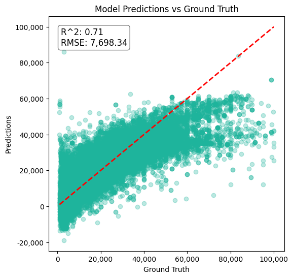

```python
y_pred_benchmark = model.predict(X_test_transformed)
plot_predictions(y_test, y_pred_benchmark)
```

A linear regression yields a RMSE of $7,698 on the held out test data.

Now we (re-)estimate the best performing gradient boosting model with the fine-tuned hyperparameters and evaulate its out-of-sample performance.

```python
model = GradientBoostingRegressor(
    n_estimators=251,
    max_depth=15,
    learning_rate=0.2,
    max_features='sqrt',
    min_samples_leaf=8,
    random_state=333).fit(X_train_transformed, y_train)
```

Model performance.

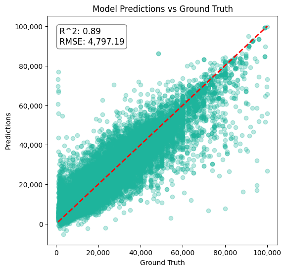

```python
y_pred = model.predict(X_test_transformed)
plot_predictions(y_test, y_pred)
```

### Model Deployment

When we talk about **deploying a model**, we mean **making a trained machine learning model available for use**. This is like putting a finished product on a store shelf so that customers can buy it.

#### FastAPI for deployment

FastAPI streamlines the deployment process by enabling developers to create **APIs** (Application Programming Interfaces), which facilitate communication between different software programs. An API includes an **inference point** where a **trained model is hosted**, allowing **users** to **send input data** and **receive real-time predictions**, thus integrating the model's capabilities into various applications without requiring users to understand the underlying technology.

```python
!fastapi dev day1_ml_fastapi.py
```

Access the API documentation at http://127.0.0.1:8000/docs.

[figure not shown]

#### Streamlit for deployment

Streamlit is an open-source app framework that simplifies the deployment of machine learning models by allowing developers to **create interactive web applications** with minimal effort. It provides a **user-friendly interface for users to input data and interact with the model** in real-time, making it easier to demonstrate the model's capabilities and gather user feedback.

```python
!streamlit run day1_ml_streamlit.py
```

Wait for the local server to open in your web browser.

[figure not shown]